# The View from the GPU: the problem of platform knowing

Adrian Mackenzie

1 Feb 2020

Abstract

This paper presents an attempt to speak appropriately about the absorption of images into platform operations and infrastructures. How should we explain the multiplicity of transformations of images and the new operational combinations they display? The paper will explore the mixture of mundane combinations and unpredictable transformations that have appeared in some spectacular platform demonstrations (e.g. AlphaGo, Facebook’s planetary settlement model ) from the standpoint of the GPU, or graphics processing units, that have become central to many predictive models working with iamges. It traces the embedding of images in a GPU-based model as a process that transforms collections into a highly condensed indexical field, a field that allows platforms to generate predictive propositions or statements about the world. In describing how predictive indexicality takes shape on platforms and machine learning models, the altered collectivity of images under platform conditions becomes more evident. The aim here is to reverse the viewpoint of most recent accounts of AI, and to unfold the labyrinth of operations that have generated the quasi-transcendence effect that animates many recent accounts and debates about AI/machine learning.

In the summer of 2018 Google employees objected to their employer’s ‘Project Maven’ contract with the US Department of Defence (Simonite n.d.). They petitioned against use of the Google platform’s machine learning and image recognition capacities for the identification of ‘38 classes of objects’ in surveillance and combat drone video footage (Pellerin 2017). Platforms generate knowledge of their fields of observation, often massively so, as part and parcel of their operation. Their knowing is problematic, ‘imbued with relational play of truth and falsehood’ (Rabinow 2003) They trouble the relationship between observers and situations. Platform knowing can be used to manipulate and control people in many different ways, as in ‘deep fake news’ (Chesney and Citron 2018) or Facebook’s ‘emotional contagion.’ Access to platform knowledge is vastly asymmetrical (as seen, for instance, in the analysis of Yahoo webcam images (Ackerman and Ball n.d.)). Errors, biases and discrimination course through so much platform knowing. Running under these controversies, there is a deeper problem of how to ground the knowing these platforms do in a liveable world, how to slow down their acceleration given that they touch almost everything: sciences, education, government, warfare, health, media and popular culture. Would we want platform knowing to be a ‘positive, experiencable operation’? (James 1975)

The problem concerns if and how platforms know. What, for instance, do platforms know about doors? It would be a step in the wrong direction to ask questions about platform epistemology, knowing subjects and known objects.  
It is far easier to work with a pragmatic understanding of knowing as acting and event derived from William James. In James’ understanding, one experience can be said to know another when a continuous path of felt transitions connects them. Knowing, as Bruno Latour re-formulates James, is ‘a *trajectory*, or, to use a more abstract term, a *vector* that projects “retroactively” its “validating power”’ (Latour 2007b, 88).[^1]  
James’ take on knowing is provocative for several reasons.  
For James, the vector character of knowing is always somewhat expedient, virtual, or shortcut. All knowing has an element of acceleration. Following that we could ask: what are the vectors of platform knowing?[^2] James’ account also points to the problem of how the shortcut paths, vectors or trajectories of knowing retroactively project validating power. Attending to validation might able us to ask how platform knowledge becomes problematically viable.

A second part of the problem is the platform. The term ‘platform’ can describe all manner of arrangements. The term is a figure for a variety speaking positions and technologies, as Tarleton Gillespie suggests (Gillespie 2010). In recent usage, it refers to an ensemble of devices, systems and networks configured so that different groups can access them (see the burgeoning platform economy literature (McAfee and Brynjolfsson 2017)).  
When I refer to platforms, I have in mind something like `Platform 3.0`, Facebook’s description of the bundle of configurations, arrangements, services it offers to developers to help them ‘connect people with Facebook’ (Facebook 2018). ‘Configured’ is a roundabout way of saying that platforms are built in data centres. Data centre platforms are inherently ambiguous phenonema. For reasons that run deep in the media, science, commerce, technology and social life they gather, we still don’t know exactly what platforms are or do.

STS offers some strong leads on approaching platforms. The work of Alberto Cambrosio and Paul Keating (Keating and Cambrosio 2003) approaches biomedical platforms in terms of knowing. They suggest that sociology should countenance new forms of platform knowledge, such as ‘regulatory objectivity’:

> Platforms embody a new form of objectivity, a regulatory one, grounded in the procedures of internal quality control, and, especially, external quality assessment (Keating and Cambrosio 2003, 332)

Although regulation in a conventional sense seems to be severely lacking in many internet platforms, the idea that platforms validate new forms of knowing by assessing and testing qualities is an important lead. STS thinking about methods of knowing the social accept and foreground ambiguities. Noortje Marres has highlighted and explored a core ambiguity of platforms studied by digital sociology:

> the distinction between the platform as instrument and platform as object is far more unstable than the [usual] formulation of these two options recognizes. We then say that social media platforms present social enquiry with an inherently *ambiguous phenomenon* (Marres 2017, 129).

The distinction is unstable because platforms are ‘objects’ designed, made, instrumented and practiced with knowing in mind. It’s not as if social researchers could land on the platform and set up field studies to find out what is happening there. The platforms are already in the process of knowing, and already platform ‘forms of knowledge_ have become the focal point of controversy in digital societies’ (Marres 2017, 184). Rather than ignore or decrie the problematic and often divisive platform knowing done in data centres, Marres suggests that social researchers should engage with the ‘critical task of specifying, and re-specifying, our objects of enquiry’ (138). Dealing with platform knowledge controversies may involve asking what seem to be very limited, detailed methodological questions about ‘how we (or they) apply their algorithms to these data’ (142).  
In any case, STS doesn’t take any thing as given, even a big thing like Facebook or Google. Jean-Christophe Plantin, Carl Lagoze, Christian Sandvig and Paul Edward’s pick up Anne Helmond’s notion of *platformization* and use it to describe how infrastructures of communication or information retrieval are embedded and expanded into daily existence through programmability, interconnection and distribution (Plantin et al. 2016).  
They emphasize the need to track ‘conflicts or subductions between infrastructures and platforms across various sectors’ (Plantin et al. 2016, 22). In platform ‘subductions’ or infrastructuralization, in instrument-object ambiguity, and in the frictions of regulatory objectivity, problems of knowing are often central.

It would be hard to find an STS academic at a desk or cafe table who isn’t relying on platform knowledges, even if its only in the form of ranked search results for images or what appears in their Twitter feed. Platforms are not ‘out there.’ When it comes to platforms, where is ‘out there’? And where is ‘in here’? It might be better to say platforms are ‘out here’ (or ‘in there).’ Pursuing how platform knowing is ‘out here’ would mean working ‘to recover,’ as Lucy Suchman recommends, ‘the lived experience and the embodied, situations and interactions of those immediately implicated in particular assemblages, the material practices and cultural imaginations that create and articulate those arrangements, and the political/economic investments that sustain them’ (Suchman 2014, 136). Recovery, in multiple senses of that term – retrieval of something lost by accident or mishap; rehabilition to health after illness or accident; and, in contrast to the frontier striving of *dis-covery* , restituting – of platform knowing may not be easy.[^3] ‘Those immediately implicated’ include ourselves out here in our consumer-audience-researcher-worker-patient-fan-citizen-teacher-player trajectories teachers across platforms. The problem of ‘out here’ is that platform knowing ferments sciences (statistical modelling for prediction and classification), techniques (especially software development), infrastructures (compute, data centre and network), media (social network and online media), popular culture (images, sound), and marketisation (buying and selling products).

## Vectorised knowing: the case of the GPU

Like an algorithm or a dataset, the GPU, or Graphics Processing Unit, is a useful thread to trace in and out of the gamut of social network media, search engines, content management systems, video and music streaming, cloud compute, not to mention scientific, engineering, military and transport platforms, often linked to each other. A GPU is semiconductor hardware, sometimes taking the form of a separate ‘card’ (in the computing rather than the greeting sense), an auxiliary chip on a motherboard or even a designated region of a processor package (for instance on the A10 Bionic processor used in recent Apple Corporations iPhones). GPUs contain circuitry specialized in the manipulation of certain geometric shapes and the rendering of images with effects of light, shadow, and texture. Over fifteen years, GPUs travel from computer gaming via science to data centre platforms. They are not the topic of any major controversy, but they bind tightly to the speedup of the knowledge economy (Stengers 2018), itself possibly a manifestation of contemporary platform capitalism (Wajcman 2015; Srnicek 2016). They are used to platformise the road vehicles made by Tesla, Mercedes-Benz, Audi, Honda, and BMW (Su 2018)) as autonomous transportation technologies.  
Crucially, and this has not been emphasised anyway near enough in current accounts to my knowledge, many of the recent ‘breakthroughs’ in AI-as-a-platform owe something to GPUs (e.g. the 2012 success of `Alexnet` in image classification (Krizhevsky, Sutskever, and Hinton 2012); Google DeepMind’s AlphaGo victory over World Go champion Lee Sedol in 2016 (Silver et al. 2016); the many encroachments into intimate spheres of life where voices, sounds, faces, things and places are known by platforms). At the centre of data centre platforms, GPUs accelerate the development and operation of machine learning predictive models, particularly the deep-learning models that for the last six years or so have rejuvenated so much interest in artificial intelligence. Major internet platforms have rapidly put GPUs at the centre of data centres, and public cloud platforms (Google Compute, Microsoft Azure, Amazon AWS) all now offer GPUs for hire. Open science platforms such as the European Open Science Cloud (EGI 2018) or Australia’s Nectar research infrastructure prominently offer GPUs to researchers.  
GPUs are not the only form of hardware specialized for platform-scale knowing (see Google Corporation’s TPU – Tensor Processor Unit – ‘powers several of our major products’ (Google 2018b) and various other ASICS – Application Specific Integrated Circuits – such as Microsoft Corporation’s ‘Project Brainwave’ (Microsoft 2018); see (Metz n.d.) for an overview).[^4] But their operation is an accessible lead on a variety of related in-house developments.

It is difficult to trace the proliferation of GPUs in all their varieties and instantiations. I assemble several GPUs, including a GPU in my office, GPUs in other offices, in data centres and at conferences. I communicate with these GPUs by looking at them, re-enacting in writing code some interactions with them, by paying to use them, by talking to a scientist about his GPUs, by reading scientists and engineers writing about their GPUs, by following conversations between software developers and programmers using GPUs, and by spectating via Youtube a Silicon Valley CEO Jensen Huang enthusing about GPUs.[^5] These materials span credit cards, office PCs, code tutorials, cloud platform infrastructures, matrices, deep learning models, ultrasound scanners, scientific publications and pre-prints, Q&A discussion threads, and high-flown well-nigh spectacular valorisation of GPUs at conference events.

I aim to plot the trajectory that seems to accelerate irresistibly from popular culture (gaming) of the 1990s via scientific computing in the 2000s into contemporary data centres post-2010 as a vector, a continuous set of felt transitions, of platform knowing. If we succeed in following the transitions that terminate in platform knowing, a statement such as a GPU product announcement might be less problematically accelerant. Here, for instance, is NVidia, the leading manufacturer of data centre GPUs, announcing a data centre GPU:

> NVIDIA® Tesla® V100 is the most advanced data center GPU ever built to accelerate AI, HPC, and graphics. It’s powered by NVIDIA Volta architecture, comes in 16 and 32GB configurations, and offers the performance of up to 100 CPUs in a single GPU. Data scientists, researchers, and engineers can now spend less time optimizing memory usage and more time designing the next AI breakthrough (Nvidia 2016).

In this announcement, the rendering of words or images on screen is not the primary concern, although still mentioned (‘graphics’). In data centres, the Tesla V100 GPU is meant to bring ‘insights’ from ‘ever-growing lakes of data’ (Nvidia 2016) within the reach of researchers.  
What carries GPUs into the centre of the data centres is an acceleration vector, a trajectory that aims to shrink the time between gathering data and knowing (‘insight’ or ‘understanding’).  
In the data centres, GPUs are aligned to a specific computational task associated with machine learning and neural net modelling in its current incarnation as ‘deep learning’ (Goodfellow, Bengio, and Courville 2016). More specifically, GPUs mainly work on collections of images derived from photographs, video footage, and various imaging platforms used in medicine and the sciences. Although they process text and sound using similar techniques, images (photographs, video, instrument images) have primacy.

Consider the challenge of viewing the fifteen million images of ImageNet, one of the most heavily used datasets in deep learning (ImageNet 2018; ILSVRC 2014). It is hard to view so many images, detached from almost all context, and having no obvious natural ordering. It is easier, perhaps only sensible, to traverse ImageNet using ideas. Searching ImageNet for ‘door’ shows that walls have openings in them. ‘Door’ forms an important element of structures such as building and room, and general ideas such as construction or artifact. The idea of a door helps define important relations such as in and out, as in ‘indoors’ and ‘outdoors.’  
We can traverse the ImageNet collection only because the images in ImageNet are all labelled by ideas such as ‘door’, ‘room’, ‘building,’ and ‘structure’. People have labelled the images, locating visual experience of a fungus, chicken runs, altars, nests, craters, pot plants, gymnastics, kitchens, baggage claim areas, crosses, spiders, and neutron stars within one of the thirty thousand or so categories stacked in the noun hierarchy drawn from Wordnet (Wordnet 2018).  
Viewed from James’ standpoint, ImageNet is a network of paths between ideas and sensible experience guided by nominalizations, or naming of things.[^6]

```
http://image-net.org/search?q=talking
Your query talking is not available yet. ImageNet is still under construction.
```

As used in deep learning, GPUs further accelerate the accelerative function of nominalization. They expedite the short-circuit path running through people categorizing sensible experience.  
Training a model on GPUs to label images using ImageNet, as Alex Krizhevsky did in 2012 (Krizhevsky, Sutskever, and Hinton 2012), means fitting a model to the sensible experience in ways that can be validated, corroborated or verified.  
This does not mean that GPUs and their ilk are where platform knowing takes place. The situation is more complicated than that. In James’ account of knowing as continuous transitions between one experience and another, feelings of transition are vital:

> In this continuing and corroborating, taken in no transcendental sense, but denoting definitely felt transitions, lies all that knowing of a percept by an idea can possibly contain or signify. Wherever such transitions are felt, the first experience knows the last one (James 1996, 56).

One experience knows another by feeling continuous, corroborating transitions. As James takes pains to point out, most corroborating remains ‘virtual’ or nascent.  
Nine times out of ten, we content ourselves with a felt tendency, a tendency suggesting that if we did follow it fully, we’d reach a sensible percept. (This allows, us for instance, to normally trust certain images without backtracking to the event of their making.) The feeling of corroboration retroacts back through the chain of transitions to generate the experience of knowing, of verification or fit between the idea and experience.

When a GPU accelerates transitions between commercially, scientifically, aesthetically or political significant ideas (of person, of thing, of disease, etc.) and images that stand in for sensible perceptions, continous transitions occur.  
We could track them through the code of the software libraries and the models that run on the GPUs, libraries such as `Torch` (Pytorch 2017), `TensorFlow` (Google 2015) or `CUDA` (Nvidia 2018b), and deep learning image recognition models such as `alexnet` (Krizhevsky, Sutskever, and Hinton 2012) or `resnet` (He et al. 2016). In the models, we would find pixel-by-pixel continuities spun between the images and the idea-classification statements such as ‘here is a dog.’ It would be difficult but not impossible to follow the trajectories and the many to-and-fro movements between images and idea, between data and knowledge.

But if knowing is to take on the full and deep sense as a platformised and implicated vector-trajectory, then locating felt transitions matters. Felt transitions are the sites of implication of people in platforms. They are the fracture zones where subduction, or pushing under, happens, where what was felt becomes unfelt. I turn to some instances of a GPU as places where felt transitions take place.

## GPU instances as felt transitions

[figure not shown]

[figure not shown]

A chain of transition links the Asus Strix NVidia 960GTX GPU I bought in late 2016 to platform knowing.  
Along this chain, some transitions are felt briefly, only to be subsumed in new short-cuts that quickly settle into the habits of platform knowing. The question is how to brake something straining to accelerate. Take for instance, the pixels in images generated for realtime 3D games by GPUs in the 1990s. GPUs architectures expanded to address more and more individual pixels. Rather than simply rendering polygons (triangles) to construct buildings, figures and things on screen, they began to add effects of light, shadow and texture (so-called pixel shaders and texture maps) to the components of those scenes. But in adding detail to images, they added data pipelines, GPU-specific memory, dedicated accelerator circuitry for specific operations, becaming a sub-system or platform within the broader computing environment of the PC. They exposed their own Application Programming Interfaces or APIs such as DirectX, OpenGL and later, CUDA, allowing programmers to access their varied functions without detailed knowledge of how the hardware worked. Their clock speeds, number of processors, bandwidth and memory increased year on year. My GeForce GTX960, for instance, gathers around 1280 compute cores, 3Gb memory, and 120Gb/s bandwidth, as well as a range of special purpose sub-systems (video-encoding, global illumination acceleration, etc.) to render 44 billion pixels to screen each second. The growing mass could be felt by gamers as they played games on higher resolution screens, immersing themselves in more detailed architectures and landscapes, awash with play of light and shadow, animating figures dressed in fabrics and equipment rendered in greater detail.  
(It could also be felt as heat and fan noise.) It could also be felt by programmers, whose sense of the GPU as a discrete, addressable platform within the PC came through the functions and commands they invoked as they configured and programmed games and other applications.

An elementary programmatic sense of the GPU as a platform might begin with these lines typed in a command line terminal:

```
lspci
```

The command lists all the devices connected to the ‘peripheral component interconnect’ and includes the GPU as one of many devices (network, USB, audio, video, memory,etc.) in the PC.

```
nvidia-smi
```

Let us shift to another GPU instance. Still at my office PC, I type another much longer command into a terminal window:

```
gcloud compute instances create gpu-instance-1 \
--machine-type n1-standard-2 --zone us-east1-d \
--accelerator type=nvidia-tesla-k80,count=1 \
--image-family ubuntu-1604-lts --image-project ubuntu-os-cloud
```

These lines configure a very different ‘gpu-instance,’ no longer in my office but in a North Virginia data centre operated by Google in the east of the US (‘us-east1’). The location the GPU is less mundane since it is now part of the Google Computer public cloud platform.

Somewhere between the two instances, the GPU has been figured as a remotely accessible object, part of the ensemble of devices and systems known as the cloud. Having this GPU is much more platform-implicated. It is one instance located in one of a dozen or more data centres around the world. I could just have well started the virtual machine in Amsterdam or Singapore, albeit at slightly greater cost. The second instance runs in my name and on my credit card account until I ‘terminate’ and delete it. The virtual machine configured in the script (an Ubuntu 16.04 operating system running on a ‘n1-standard’ dual CPU) would then spin down or move on to some other scheduled task.

Under what circumstances does the transition from a GTX960 in my office to ‘gpu-instance-1’ in North Virginia become so seamless? What continuities and corroborating hold between the two instances? While `gpu-instance-1` is still running, I login into the virtual machine and type the same commands I did for my office PC:

```
lspci
nvidia-smi
```

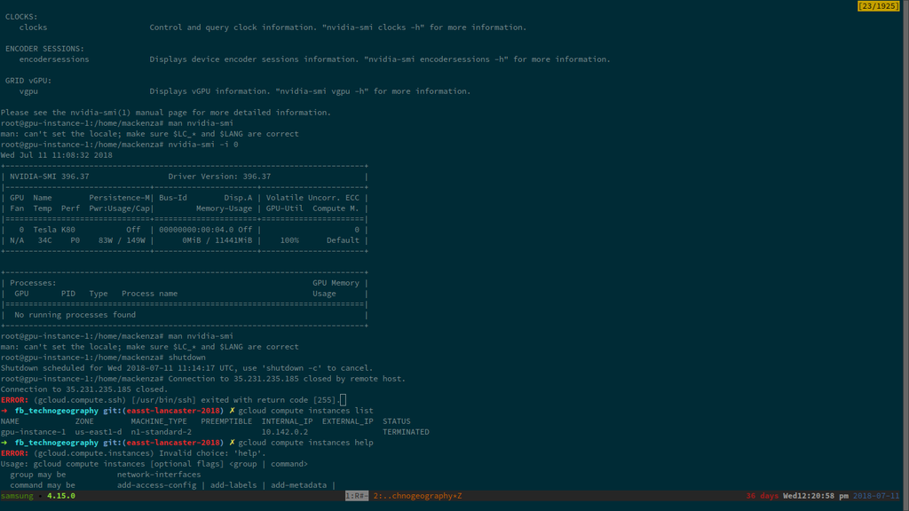

The GPU instance is less mundane since it is now a Tesla K80, the “world’s most popular GPU” (Nvidia 2018c), a GPU designed to lower energy costs for data centres. But the commands I direct to the 960GTX and K80 are identical and the output of the commands is quite similar, suggesting a continuity has been established. The alignments and associations I have to my mundane office PC’s GPU are almost indiscernible from those I have to the Google Compute instance.  
In order for an experience of infrastructurally scaled sameness to appear in my terminal emulator (the same commands work in both places), geographies, software differences, and hardware specificities have been overcome.

## Implicated scientists: from Maxwell to Volta

A lead come from scientists working with GPUs. The path that takes the GPU from gaming platform to platform knowing passes through scientists and sciences. I turn away from my GPU and walk to another part of campus to knock on the door of an epidemiologist who has been using GPUs for epidemic modelling since 2008. In my interviewee’s office, the packaging for an NVidia Tesla C2075 professional GPU (circa 2011) lies above the shelf of books on lineear algebra, *Bayesian Data Analysis (3rd edition)* and *Numerical Recipes in C*. I ask him about the Nvidia GPU carton and he dismisses: ‘oh, that’s an old one, out of date.’ His current Tesla GPUs were furnished as a grant-in-kind by NVidia. They are ‘co-located’ in a specially bought server somewhere in the Information System Services facilities on campus. ( I don’t manage to visit the ISS facility. If I did, would it look much different to what I see in my office PC?) From my PC’s GPU to the GPUs co-located – the act of placing multiple entities in a single location – in ISS, the path runs through scientists such as my interviewee.

The path to the GPU, followed by sciences ranging across astrophysics, finance, chemistry, molecular biology, epidemiology and of course computer science, might seem short, as easy to follow as the path from my office in sociology to the medical school. When I ask my interviewee ‘what is a GPU?’, he replies with a brief account of GPU-based calculation: ‘it carries out calculation specialized on a matrix, such as a screen. GPUs are designed to make matrix calculations very fast.’ Two stories of acceleration follow, one concerning chips and one concerning networks. GPUs address the problem, he went on to explain, of Moore’s Law running into the physical limits of miniaturisation.[^7]  
GPUs continue to accelerate when CPUs can’t. Their growing number of parallel cores overtakes the increasingly difficult miniaturisation of transistors on which Moore’s Law has relied until relatively recently (2010 or so).  
GPUs also ease frictions in large-scale scientific computation using networks. Networked computing clusters were developed and widely used post-2000 to accelerate scientific computation. (Prior to ‘the cloud,’ scientists often referred to them as ‘the grid.’) But clusters were hard to set up and program. And they bogged down shunting data along network cables between machines. The GPU architecture of many cores keeps the paths taken by data much shorter.

NVidia itself frequently re-counts the end-of-Moore’s-Law narrative and the triumph of parallelisation in its announcements, product releases and blogs. Several years prior to my interview, my epidemiologist had already been interviewed by NVidia for its news blog (Nemire 2015). A collection of interviewers with scientists during the years 2013-2017 reiterated the point: GPUs accelerate the science of earthquakes, the ‘luminosity of beam dynamics’, complex fluid flows in rock, solar storms, ‘large scale object detection’ and ‘spectral graph partitioning.’ But the acceleration narrative, even as it is repeated by my interviewee in comparing his current GPUs with the older ones, moves too quickly. Even with these two modifications – failure of Moore’s Law and frictions in the grid – the accelerationist narrative moves slightly too quickly. To grasp the vectors of knowing in the contemporary platformisation of the GPU, we still need to trace the implication of those immediate to the GPU over time. Between my ancient Greek owl with its Maxwell architecture, and the more recent data centre Tesla or Volta GPUs, the differences are not only scalar, as if the sheer quantity of transistors make a short cut from gaming to knowing, as if accelerating GPUs are like polished wooden balls rolling down Galileo’s inclined plane, covering the same distance in ever shorter times.

## Hacking the GPU in retrospect

All knowledge accelerates. Acceleration practices multiply in the sciences. Notations, devices, concepts, standards, collaborations, disciplines, and all the elements of scientific knowledge have accelerative tendencies. But knowing also needs a validating after-effect, the retroactive projection rippling back through the felt transitions of a trajectory, confirming or corroborating the sense that one experience – an idea, a concept, a calculation – leads us to another – the sensible experience of, say, a door.

[figure not shown]

## A matrix of implications

Scientists implicate themselves with GPUs around the figure of the matrix. In response to this implication, GPUs became something designed, as my interview put it, to calculate matrices fast. They weren’t designed to calculate matrices fast from the outset, but have become fast at matrix calculations in the wake of the many scientists who saw GPUs as matrix multipliers. What is a matrix?

/

[figure not shown]

/

At this point, things could easily slide too quickly again, for matrices, just as much as devices like GPUs and platforms spread across data centres, are knowledge accelerants. But following James’ injunction to follow the felt transitions, the corroboration and virtualities of knowing, let us return to the command line console to see how matrices are actually rendered computable on GPUs. We have already seen a script to initialize a GPU instance in the cloud. But that one-line script, as shown in the previous code excerpt, is not complete. It needs a second line:

```
--metadata startup-script=
    '#!/bin/bash
    echo "Checking for CUDA and installing."
    if ! dpkg-query -W cuda-9-0; then
        curl -O http://developer.download.nvidia.com/compute/cuda/repos/ubuntu1604/x86_64/cuda-repo-ubuntu1604_9.0.176-1_amd64.deb
        dpkg -i ./cuda-repo-ubuntu1604_9.0.176-1_amd64.deb
        apt-key adv --fetch-keys http://developer.download.nvidia.com/compute/cuda/repos/ubuntu1604/x86_64/7fa2af80.pub
        apt-get update
        apt-get install cuda-9-0 -y
    fi'
```

The comment ‘Checking for CUDA and installing’ just about sums it up. The GPU becomes a matrix calculator today (and for the last ten years or so) in the wake of some software installation (check if CUDA is installed, if not, download it, install it, check for updates, install updates).

A sharp upturn in GPU-related publications and pre-publication begins soon after the release of the first versions of CUDA in 2007 (and can be seen in both the plots of journal publications and arXiv pre-prints around that time). My interviewee described his own GPU learning not in terms of parallel streaming processors or pixel shaders but in terms of CUDA: ‘I went straight to the CUDA C programming guide’ (see (Nvidia 2018b)). Rather than rendering matrices calculable in either abstract mathematical or concrete hardware-specific senses, CUDA constructs an experience of continuity between existing programming practices and GPU-programming practices. As discussions in computer science journals such as ACM Queue noted at the time, CUDA is a ‘minimal extension of the C and C++ programming languages’ (Nickolls et al. 2008, 43).  
What CUDA supplies – a ‘platform and programming model’ that only slightly departs from standard programming practices – was perhaps just as important as the GPU hardware.

```
#include <iostream>
#include <math.h>

// function to add the elements of two arrays
void add(int n, float *x, float *y)
{
  for (int i = 0; i < n; i++)
      y[i] = x[i] + y[i];
}

int main(void)
{
  int N = 1<<20; // 1M elements

  float *x = new float[N];
  float *y = new float[N];

  // initialize x and y arrays on the host
  for (int i = 0; i < N; i++) {
    x[i] = 1.0f;
    y[i] = 2.0f;
  }

  // Run kernel on 1M elements on the CPU
  add(N, x, y);

  // Check for errors (all values should be 3.0f)
  float maxError = 0.0f;
  for (int i = 0; i < N; i++)
    maxError = fmax(maxError, fabs(y[i]-3.0f));
  std::cout << "Max error: " << maxError << std::endl;

  // Free memory
  delete [] x;
  delete [] y;

  return 0;
}
```

```
#include <iostream>
#include <math.h>

// Kernel function to add the elements of two arrays
__global__
void add(int n, float *x, float *y)
{
  int index = blockIdx.x * blockDim.x + threadIdx.x;
  int stride = blockDim.x * gridDim.x;
  for (int i = index; i < n; i += stride)
    y[i] = x[i] + y[i];
}

int main(void)
{
  int N = 1<<20;
  float *x, *y;

  // Allocate Unified Memory – accessible from CPU or GPU
  cudaMallocManaged(&x, N*sizeof(float));
  cudaMallocManaged(&y, N*sizeof(float));

  // initialize x and y arrays on the host
  for (int i = 0; i < N; i++) {
    x[i] = 1.0f;
    y[i] = 2.0f;
  }

  // Run kernel on 1M elements on the GPU
  int blockSize = 256;
  int numBlocks = (N + blockSize - 1) / blockSize;
  add<<<numBlocks, blockSize>>>(N, x, y);

  // Wait for GPU to finish before accessing on host
  cudaDeviceSynchronize();

  // Check for errors (all values should be 3.0f)
  float maxError = 0.0f;
  for (int i = 0; i < N; i++)
    maxError = fmax(maxError, fabs(y[i]-3.0f));
  std::cout << "Max error: " << maxError << std::endl;

  // Free memory
  cudaFree(x);
  cudaFree(y);
  return 0;
}
```

## Developers platformise the data centres

CUDA renders acceleration smooth by subducting the GPU parallelism that we see in the scientist’s articles, in the NVidia blogs, in the equipping of data centres with GPUs and in the burst of platform knowing. But scientists do not make and run platforms such as Instagram, Twitter, Google or Amazon.  
Platforms, or least the most well-known platforms, are not populated by scientists. They may not even use them very much in their work. When asked why he didn’t use GPUs on cloud compute platforms, my interviewee responded: “I haven’t found a business model that makes it worthwhile.” Developers and software engineers make platforms. And platforms are made, in part, for developers, which is why the CUDA documentation can be found in NVidia’s ‘Developer Zone’ not a ‘Scientist Zone’, and why Facebook has a high-level domain developers.facebook.com. Developers’ are not scientists, even if their work owes much to scientists. They construct the continuities that allow platform knowing to move between a GPU in an office PC and GPUs in data centres.

[figure not shown]

On the programming Q&A site, StackOverflow.com, posted questions are tagged by users. Unlike the keywords for scientific publications found on Thomson Scientific’s Web of Science or the arXiv.org pre-print repository, the tags are single words. A plot of the tags associated with the tag `cuda` since 2008 presents several tendencies. The figure shows the one hundred most frequent tags.[^8] The tags `cuda` and `gpu` have been removed. The remaining tags have been coded according to categories important in developer’s work (platforms, languages, programming work, matrices, parallelism, and one other category, images).  
Prominent concern relate to the work of programming (compilers, development tools, errors, profiling), specific programming languages (C, C++, Python, Java, Matlab, etc.) and underlying platforms (linux, Windows, Tesla GPUs). Questions and discussion around matrices, parallelisation and optimisation take many forms, sometimes relating to specific software libraries such as `cublas` or `numpy`.

[figure not shown]

Images associated with cuda on StackOverflow.com

The final category – images – stands out here. Tags such as `image`, `image processing`, `torch` and thirty similar tags account for around 10% of the total number of tags used in the `cuda`-tagged posts. Although they are not the most common tags in use, they are significant. Some tags relate to computer graphics (for instance, `directx` posts probably relate to game programming, and `raytracing` is a technique for creating photo-realistic images, etc.),  
Leaving these tags aside, the remainder – `neural network`, `machine learning`, `keras`, `theano`, `tensorflow`, `caffe`, `opencv` – bear on the problem of knowing images. These tags mention models, libraries and techniques that process images in order to recognise faces, places and things in images (as in the `opencv` or open computer vision library) or to classify things visible in images.

## Infrastructuralising GPUs: ‘the more you buy, the more you save’

As scientists, developers and perhaps social researchers implicate themselves with GPUs, they also contribute way points and connective elements to another trajectory, a retroactive validation of platform knowing. We know that cloud data centres operated by technology companies such as IBM, Microsoft, Google, Amazon and others not only anchor social media or business software platforms. They platformise domains of social life.

What is platformisation? Anne Helmond describes platformisation as a double logic of decentralization or distribution of platform features (through APIs, apps, and other layers of software and hardware) and centralization of data collection (Helmond 2015, 5). Helmond defines platformization as an ‘economic model’ (8), which it is, but it only becomes economic when the data is transformed into knowledge forms with some referential purchase, some terminus in the world, in James’ terms.

In constantly varying stream of statements between 2009 and 2018, Huang’s keynote addresses to GTC audiences wrangles GPUS into association with gamers, designers, scientists, software engineers, developers and data centre operators. The structure of Huang’s speeches has remained remarkably stable. He introduces a new GPU chip, architecture or server product, and runs a demonstration of the product working on a scientific, engineering, or commercial challenge, exhorting the audience to marvel at the ingenuity or importance of the demonstrations and to buy more GPUs. The statements, the elements of the GPU discursive formation, refer to cost, energy usage, time, research and, pervasively, the economic value of knowledge.

Huang does not address scientists as such, even if he often describes and draws on their work with GPUs. He speaks to developers in their language. For instance, at GTC2017, much of the hour-long talk dwells on how deep learning done on GPUs can save money for data centres (‘that’s right; the more you buy, the more you save’) (Nvidia 2017).[^11] Huang’s talk of cost saving assumes, without much justification, that the audience in the auditorium and on Youtube will be sensitive to the problems of how to manage data centre-scale image collections and will want to use deep learning to do that. Huang invokes scientific knowledges but highlights the problems of regulating and accelerating knowledge.

At GTC2018, for instance, he presents `Clara Clara` as a platformisation of scattered biomedical platforms, in this case ultrasound scanners:

> There are three, four, or five million medical instruments that are installed all over hospitals all over the world. … Can we take advantage of the same basic techniques … where you connect devices connected to data centres, and those data centers essentially have [GPU] supercomputers that are virtualized?’ (Nvidia 2018d).

Huang proposes `Clara Clara` as an upgrade of all existing ultrasound imaging scanners.

> Project `Clara Clara` … is a medical imaging supercomputer. But what it is is a data centre-virtualized remoted multi-user medical computational medical instrument. … It’s possible for us to actually virtually upgrade every single actual instrument (Nvidia 2018d).

`Clara Clara`’s introduction, as is the convention in technology demonstration, takes the form of a before-and-after comparison. The comparison register some kind of acceleration on, ironically given the decoupling of GPUs from displays, on a large screen.  
The idea, as Huang does on to show, is use the internet connections found on many ultrasound machines to feed images into a data centre. Then, NVidia’s latest GPU server (a DXG-2 (Nvidia 2018a)) running trained deep learning models, will sharpen and segment – locate and label significant image elements simply not visible or discernable even to experts sat by the scanners.

At this point, Huang shows 3-D coloured animation of a beating heat, with the left ventricle segmented as a distinct, coloured mass, and accelerates his own talk:

> I’m so excited. We can that we see basically the chamber here and we analyze most of the motion of the left ventricle by using deep learning. … It’s a fully convolutional neural network in 3D called `vnet` (Nvidia 2018d).

Finally, done with `Clara` (now a NVidia product (Nvidia 2018e)), Huang turns away from the biomedical platform to insist on the acceleration of deep learning. For ten years of GTC keynote addresses, Huang has been excited by GPU-based accelerations of entertainment, engineering design and now AI.  
Unlike other Silicon Valley platform proponents, Huang’s excitement does not emanate from the internet ‘fog of freedom’ (Kelty 2014). It is an epistemic affect, a feeling of transition, which retrospectively validates the power of GPUs to change knowing. For Huang, sciences and data science/AI in particular vectorize the marketing of sales of GPUs for data centres.  
The exact topic of the science – medical imaging, molecular modelling, astrophysics or epidemiology – serves as a platform for comparison of metrics such as FLOPS (Floating Point Operations Per Second).  
Huang constantly enrols and substitutes GPU-based demonstrations for CPU-based science.  
He recruits scientists as proponents of GPUs. Many scientists speak at GTC conferences. But the scientists themselves, having made the GPU into a vector of knowing, are carried along by the multiplying GPUs. They buy or rent GPUs, and find their work increasingly drawn into the data centre by the logics of acceleration and scale the GPUs demonstrate.

## Conclusions

In *The Meaning of Truth*, James describes how realities verify and validate their own ideas:

> Without such intermediating portions of concretely real experience the pragmatist sees no materials out of which the adaptive relation called truth can be built up (James 1975, 76)

Given GPUs as ‘intermediating portions of concretely real experience,’ platform knowing, like any other, is a trajectory that substitutes ideas for the continuities of sensible experience.  
Without GPUs or the TPUs or the FPGAs, the adaptive relation called truth lacks materials.

Two facets of GPU intermediating are constructive. Scientists do the accelerating. Developers platformise the acceleration. Scientists implicate GPUs with matrices, with the additions and multiplication of vectors. Their GPU publication frenzy points to a felt transition in knowing. Matrix and vector operations tend to proliferate, partly as an outgrowth of accelerations in science. Configured rightly, GPUs ease the frictions of acceleration. The scientists reconfiguration of GPUs retroacts on the GPUs themselves. They become parallel stream processors, as well as graphics processors. Their architectures capture matrix multiplication in all its science and engineering variants: linear algebra, vector field flow, fast Fourier transforms, neural networks, etc. In their wake, developers implicate GPUs with platforms, setting and adjusting alignments between CPUs and GPUs, between data and models. The layers and libraries of GPU software render differences between platforms (office PC, ISS server, cloud compute) barely felt, except as changes in scale, as quantifiable differences in speed and cost. Moved from the office and lab PCs to the centre of the data centre, packed in racks, GPUs transform platform knowing, re-shaping the streams and accumulations of images, sound, and words there into predictive models replete with categories, classifications, identifications and recognition.

In turn, the scientists’ entanglements with GPUs are captured in a broader economisation. GPUs deeply platformise existing scientific, biomedical and other knowledge platforms. Subducting biomedical imaging platforms, data centre GPUs retroactively upgrade them, affirming in the process the singular value of acceleration in platform knowing. The feeling of acceleration becomes the principal felt transition. No other value competes in this knowing.

And what of others’ implication in platform knowing? I’m curious to see if my trajectory from office PC to epidemiologist to cloud GPUs in their increasingly subducted instances resonates with any others. The lines of code, the invocation of instances and running of models may not be familiar to most STS researchers, even if much STS research concerns platforms and infrastructures in their many scientific, industrial, governmental and media configurations.

The lessons I draw from the instances of GPUs visited in this discussion concern ambivalence, implication and knowing. It is impossible not to be ambivalent about platform knowing. The ambivalence comes partly from implication. My knowing of the platforms is conditioned by those platforms and my implication with them. From the GPU, my office GPU in particular, forlornly commercial, unwittingly caught up in debates about knowledge, spared the heat and noise of gaming, I learn of the many threads and blocks put in place to make it possible.

## References

Ackerman, Spencer, and James Ball. n.d. “Optic Nerve: Millions of Yahoo Webcam Images Intercepted by GCHQ.” *The Guardian: US News*. Accessed October 26, 2018. https://www.theguardian.com/world/2014/feb/27/gchq-nsa-webcam-images-internet-yahoo.

Bolz, Jeff, Ian Farmer, Eitan Grinspun, and Peter Schröoder. 2003. “Sparse Matrix Solvers on the GPU: Conjugate Gradients and Multigrid.” In *ACM Transactions on Graphics (TOG)*, 22:917–24. ACM.

Buck, I. 2007. “GPU Computing: Programming a Massively Parallel Processor.” In *International Symposium on Code Generation and Optimization (CGO’07)*, 17–17.

Camins, Angel Sevilla Camins’. 2018. “Easy CI/CD of GPU Applications on Google Cloud Including Bare-Metal Using Gitlab and Kubernetes.” December 14, 2018. https://angelsevillacamins.github.io//Easy-CICD-of-GPU-applications-on-Google-Cloud/.

Chellapilla, Kumar, Sidd Puri, and Patrice Simard. 2006. “High Performance Convolutional Neural Networks for Document Processing.” In *Tenth International Workshop on Frontiers in Handwriting Recognition*. Suvisoft.

Chesney, Robert, and Danielle Keats Citron. 2018. “Deep Fakes: A Looming Challenge for Privacy, Democracy, and National Security.” SSRN Scholarly Paper ID 3213954. Rochester, NY: Social Science Research Network. https://papers.ssrn.com/abstract=3213954.

Delfanti, Alessandro. 2016. “Beams of Particles and Papers: How Digital Preprint Archives Shape Authorship and Credit.” *Social Studies of Science* 46 (4): 629–45.

EGI. 2018. “EGI | How to Predict Social Media Trends?” 2018. https://www.egi.eu/use-cases/research-stories/how-to-predict-social-media-trends/.

Evans, Bob. 2018. “Amazon to Become #1 in Cloud-Computing Revenue by Beating IBM’s $17 Billion.” Forbes. January 26, 2018. https://www.forbes.com/sites/bobevans1/2018/01/26/amazon-to-become-1-in-cloud-computing-revenue-by-beating-ibms-17-billion/.

Evans, Richard, and Jim Gao. 2016. “DeepMind AI Reduces Google Data Centre Cooling Bill by 40%.” DeepMind. July 20, 2016. https://deepmind.com/blog/deepmind-ai-reduces-google-data-centre-cooling-bill-40/.

Facebook. 2016. “Facebook to Open-Source AI Hardware Design.” Facebook Code. 2016. https://code.facebook.com/posts/1687861518126048/facebook-to-open-source-ai-hardware-design/.

———. 2018. “Facebook for Developers.” 2018. https://developers.facebook.com/.

Gillespie, Tarleton. 2010. “The Politics of ‘Platforms’.” *New Media & Society* 12 (3): 347–64.

Goodfellow, Ian, Yoshua Bengio, and Aaron Courville. 2016. *Deep Learning*. MIT press. https://books.google.co.uk/books?hl=en&lr=&id=omivDQAAQBAJ&oi=fnd&pg=PR5&dq=goodfellow+deep+learning&ots=MMM_cvoDTZ&sig=fOx5eav7jldNkuwcNqd4DgJEGAc.

Google. 2015. “TensorFlow – an Open Source Software Library for Machine Intelligence.” 2015. https://www.tensorflow.org/.

———. 2018a. “Cloud Speech-to-Text - Speech Recognition.” Google Cloud. 2018. https://cloud.google.com/speech-to-text/.

———. 2018b. “Cloud TPUs - ML Accelerators for TensorFlow | Cloud TPU.” Google Cloud. 2018. https://cloud.google.com/tpu/.

Gunnarsdóttir, Kristrún. 2005. “Scientific Journal Publications: On the Role of Electronic Preprint Exchange in the Distribution of Scientific Literature.” *Social Studies of Science* 35 (4): 549–79. https://doi.org/10.1177/0306312705052358.

He, Kaiming, Xiangyu Zhang, Shaoqing Ren, and Jian Sun. 2016. “Identity Mappings in Deep Residual Networks.” In *European Conference on Computer Vision*, 630–45. Springer.

Helmond, Anne. 2015. “The Platformization of the Web: Making Web Data Platform Ready.” *Social Media + Society* 1 (2): 2056305115603080. https://doi.org/10.1177/2056305115603080.

ILSVRC. 2014. “ImageNet Large Scale Visual Recognition Competition 2014 (ILSVRC2014).” 2014. http://www.image-net.org/challenges/LSVRC/2014/.

ImageNet. 2018. “ImageNet.” 2018. http://www.image-net.org/.

James, William. 1975. *The Meaning of Truth*. Edited by Fredson Bowers and Ignas K. Skrupskelis. Harvard University Press.

———. 1996. *A Pluralistic Universe*. Lincoln: Nebraska University Press.

Keating, Peter, and Alberto Cambrosio. 2003. *Biomedical Platforms : Realigning the Normal and the Pathological in Late-Twentieth-Century Medicine*. Inside Technology. Cambridge, Mass.: MIT Press. http://www.loc.gov/catdir/toc/fy042/2002044414.html.

Kelty, Christopher. 2014. “The Fog of Freedom.” In *Media Technologies: Essays on Communication, Materiality, and Society*, edited by Tarleton Gillespie, 129–37. Cambridge ; Malden, MA: MIT Press.

King, Katie. 2012. *Networked Reenactments: Stories Transdisciplinary Knowledges Tell*. Durham [N.C.]: Duke University Press.

Krizhevsky, Alex, Ilya Sutskever, and Geoffrey E. Hinton. 2012. “Imagenet Classification with Deep Convolutional Neural Networks.” In *Advances in Neural Information Processing Systems*, 1097–1105. http://papers.nips.cc/paper/4824-imagenet-classification-with-deep-convolutional-neural-networks.

Krüger, Jens, and Rüdiger Westermann. 2003. “Linear Algebra Operators for GPU Implementation of Numerical Algorithms.” In *ACM Transactions on Graphics (TOG)*, 22:908–16. ACM.

Latour, Bruno. 2007a. “A Textbook Case Revisited. Knowledge as Mode of Existence.” In *Hanbook of Science and Technology Studies*, edited by Edward J Hackett, Olga Amsterdamska, Michael Lynch, and Judy Wacjman, 3rd ed. Cambridge, MA: MIT Press.

———. 2007b. *Reassembling the Social: An Introduction to Actor-Network-Theory*. New Ed. OUP Oxford.

Latour, Bruno, Philippe Mauguin, and Geneviève Teil. 1992. “A Note on Socio-Technical Graphs.” *Social Studies of Science* 22 (1): 33–57. http://www.jstor.org.ezproxy.lancs.ac.uk/stable/370223.

Lim, Nathan. 2017. “Why Does Nvidia Limit the Number of GPUs You Can Buy at 2?” Quora. June 2017. https://www.quora.com/.

Lynch, Michael. 2013. “Ontography: Investigating the Production of Things, Deflating Ontology.” *Social Studies of Science* 43 (3): 444–62. https://doi.org/10.1177/0306312713475925.

Mackenzie, Adrian. 2012. “More Parts Than Elements: How Databases Multiply.” *Environment and Planning D: Society and Space* 30 (2): 335–50.

———. 2019. “The Marketisation of Calculation.” *Economy and Society* TBA.

Marres, Noortje. 2017. *Digital Sociology: The Reinvention of Social Research*. 1 edition. Malden, MA: Polity.

McAfee, Andrew, and Erik Brynjolfsson. 2017. *Machine, Platform, Crowd : Harnessing Our Digital Future*. New York: W. W. Norton & Company.

Metz, Cade. n.d. “Big Bets on A.I. Open a New Frontier for Chip Start-Ups, Too.” *The New York Times: Technology*. Accessed May 25, 2018. https://www.nytimes.com/2018/01/14/technology/artificial-intelligence-chip-start-ups.html.

Microsoft. 2018. “Project Brainwave.” Microsoft Research. 2018. https://www.microsoft.com/en-us/research/project/project-brainwave/.

Mott, Nathaniel. 2017. “As Prices Soar, Graphics Card Manufacturers Appeal to Cryptocurrency Miners.” Tom’s Hardware. June 26, 2017. https://www.tomshardware.com/news/graphics-cards-prices-mining-cryptocurrency,34879.html.

Nemire, Brad. 2015. “Using GPUs to Accelerate Epidemic Forecasting.” NVIDIA Developer Blog. July 22, 2015. https://devblogs.nvidia.com/gpus-accelerate-epidemic-forecasting/.

Nickolls, John, Ian Buck, Michael Garland, and Kevin Skadron. 2008. “Scalable Parallel Programming with CUDA.” *Queue* 6 (2): 40. http://portal.acm.org/citation.cfm?doid=1365490.1365500.

Nvidia. 2016. “NVIDIA Tesla V100.” NVIDIA. 2016. https://www.nvidia.co.uk/data-center/tesla-v100/.

Nvidia, dir. 2017. *Nvidia GPU Technology Conference(GTC) 2017 Keynote*. https://www.youtube.com/watch?v=hpxTSvu1HUQ.

———. 2018a. “NVIDIA DGX-2: Enterprise AI Research System.” NVIDIA. 2018. https://www.nvidia.com/en-au/data-center/dgx-2/.

———. 2018b. “Programming Guide :: CUDA Toolkit Documentation.” 2018. https://docs.nvidia.com/cuda/cuda-c-programming-guide/index.html#features-and-technical-specifications.

———. 2018c. “Tesla K80.” NVIDIA. 2018. https://www.nvidia.com/en-gb/data-center/tesla-k80/.

———, dir. 2018d. *GTC 2018 Keynote with NVIDIA CEO Jensen Huang*. https://www.youtube.com/watch?v=95nphvtVf34.

———. 2018e. “NVIDIA CLARA Platform.” NVIDIA Developer. September 7, 2018. https://developer.nvidia.com/clara.

Pellerin, Cheryl. 2017. “Project Maven to Deploy Computer Algorithms to War Zone by Year’s End.” U.S. DEPARTMENT OF DEFENSE. July 21, 2017. https://dod.defense.gov/News/Article/Article/1254719/project-maven-to-deploy-computer-algorithms-to-war-zone-by-years-end/.

Plantin, Jean-Christophe, Carl Lagoze, Paul N Edwards, and Christian Sandvig. 2016. “Infrastructure Studies Meet Platform Studies in the Age of Google and Facebook.” *New Media & Society*, August, 1461444816661553. https://doi.org/10.1177/1461444816661553.

Pytorch. 2017. “Torch.Nn — PyTorch Master Documentation.” 2017. http://pytorch.org/docs/0.3.0/nn.html#conv3d.

Rabinow, Paul. 2003. *Anthropos Today. Reflections on Modern Equipment*. Princeton and Oxford: Princeton University Press.

Raina, Rajat, Anand Madhavan, and Andrew Y. Ng. 2009. “Large-Scale Deep Unsupervised Learning Using Graphics Processors.” In *Proceedings of the 26th Annual International Conference on Machine Learning*, 873–80. ICML ’09. New York, NY, USA: ACM. http://doi.acm.org/10.1145/1553374.1553486.

Reyes-Galindo, Luis. 2016. “Automating the Horae: Boundary-Work in the Age of Computers.” *Social Studies of Science* 46 (4): 586–606. https://doi.org/10.1177/0306312716642317.

Silver, David, Aja Huang, Chris J. Maddison, Arthur Guez, Laurent Sifre, George Van Den Driessche, Julian Schrittwieser, Ioannis Antonoglou, Veda Panneershelvam, and Marc Lanctot. 2016. “Mastering the Game of Go with Deep Neural Networks and Tree Search.” *Nature* 529 (7587): 484–89.

Simonite, Tom. n.d. “Pentagon Will Expand AI Project Prompting Protests at Google.” *Wired*. Accessed October 24, 2018. https://www.wired.com/story/googles-contentious-pentagon-project-is-likely-to-expand/.

Srnicek, Nick. 2016. *Platform Capitalism*. Cambridge, UK ; Malden, MA: Polity Press.

Steinkraus, Dave, Ian Buck, and P. Y. Simard. 2005. “Using GPUs for Machine Learning Algorithms.” In *Eighth International Conference on Document Analysis and Recognition (ICDAR’05)*, 1115–20. IEEE.

Stengers, Isabelle. 2018. *Another Science Is Possible: A Manifesto for Slow Science*. John Wiley & Sons.

Su, Jean Baptiste. 2018. “Why Tesla Dropped Nvidia’s AI Platform for Self-Driving Cars and Built Its Own.” Forbes. August 18, 2018. https://www.forbes.com/sites/jeanbaptiste/2018/08/15/why-tesla-dropped-nvidias-ai-platform-for-self-driving-cars-and-built-its-own/.

Suchman, Lucy. 2014. “Mediations and Their Others.” In *Media Technologies: Essays on Communication, Materiality, and Society*, edited by Tarleton Gillespie, 129–37. Cambridge ; Malden, MA: MIT Press.

Wajcman, Judy. 2015. *Pressed for Time: The Acceleration of Life in Digital Capitalism*. University of Chicago Press.

Weiskopf, Daniel Weiskopf Matthias Hopf Thomas. 2001. “Hardware-Accelerated Visualization of Time-Varying 2D and 3D Vector Fields by Texture Advection via Programmable Per-Pixel Operations.”

Wordnet. 2018. “WordNet | A Lexical Database for English.” 2018. https://wordnet.princeton.edu/.